# Angina

# 1 Description of DataSchema variable

The description of harmonised variable is the following:

- Short name: `h_angina`
- Variable label: `History of angina`
- Variable description: `history of angina`
- Domain: `Diseases`
- Value type: `categorical`
- Category coding:

| **Code** | **Category Label** |
| --- | --- |
| 0 | no history of angina |
| 1 | history of angina |

- Category missings:

| **Code** | **Category Label** |
| --- | --- |
| 991 | CAPI/interviewer error |
| 992 | Impute |
| 993 | Disable to measure |
| 994 | Not attempt/not done |
| 995 | Does not answer |
| 996 | Not applicable |
| 997 | Refuse |
| 998 | Do not know |
| 999 | Missing |

- Short name: `h_angina_age`
- Variable label: `Age first diagnosed angina`
- Variable description: `The age first told had angina diagnosis`
- Domain: `Diseases`
- Value type: `Continuous`
- Category missings:

| **Code** | **Category Label** |
| --- | --- |
| 991 | CAPI/interviewer error |
| 992 | Impute |
| 993 | Disable to measure |
| 994 | Not attempt/not done |
| 995 | Does not answer |
| 996 | Not applicable |
| 997 | Refuse |
| 998 | Do not know |
| 999 | Missing |

# 2 Data process

## 2.1 England

### 2.1.1 Wave 1

#### 2.1.1.1 Study-specific variable description

| **Name** | `hedim01` | `hedim02` | `hedim03` | `hedim04` | `hedim05` | `hedim06` | `hedim07` | `heaga` |
| --- | --- | --- | --- | --- | --- | --- | --- | --- |
| **Label** | `MERGED - Has a doctor ever told you that you [have/have had] any of the conditions in this card? {heart conditions}` | `MERGED - Has a doctor ever told you that you [have/have had] any of the conditions in this card? {heart conditions}` | `MERGED - Has a doctor ever told you that you [have/have had] any of the conditions in this card? {heart conditions}` | `MERGED - Has a doctor ever told you that you [have/have had] any of the conditions in this card? {heart conditions}` | `MERGED - Has a doctor ever told you that you [have/have had] any of the conditions in this card? {heart conditions}` | `MERGED - Has a doctor ever told you that you [have/have had] any of the conditions in this card? {heart conditions}` | `MERGED - Has a doctor ever told you that you [have/have had] any of the conditions in this card? {heart conditions}` | `Approximately how old were you when first told by a doctor that you had angina? {years}` |
| **Table name** | `wave_1_core_data_v3` | `wave_1_core_data_v3` | `wave_1_core_data_v3` | `wave_1_core_data_v3` | `wave_1_core_data_v3` | `wave_1_core_data_v3` | `wave_1_core_data_v3` | `wave_1_core_data_v3` |
| **Categories** | `1 = High blood pressure or hypertension` `2 = Angina` `3 = A heart attack (including myocardial infarction or coronary)` `4 = Congestive heart failure` `5 = A heart murmur` `6 = An abnormal heart rhy… | `1 = High blood pressure or hypertension` `2 = Angina` `3 = A heart attack (including myocardial infarction or coronary)` `4 = Congestive heart failure` `5 = A heart murmur` `6 = An abnormal heart rhy… | `1 = High blood pressure or hypertension` `2 = Angina` `3 = A heart attack (including myocardial infarction or coronary)` `4 = Congestive heart failure` `5 = A heart murmur` `6 = An abnormal heart rhy… | `1 = High blood pressure or hypertension` `2 = Angina` `3 = A heart attack (including myocardial infarction or coronary)` `4 = Congestive heart failure` `5 = A heart murmur` `6 = An abnormal heart rhy… | `1 = High blood pressure or hypertension` `2 = Angina` `3 = A heart attack (including myocardial infarction or coronary)` `4 = Congestive heart failure` `5 = A heart murmur` `6 = An abnormal heart rhy… | `1 = High blood pressure or hypertension` `2 = Angina` `3 = A heart attack (including myocardial infarction or coronary)` `4 = Congestive heart failure` `5 = A heart murmur` `6 = An abnormal heart rhy… | `1 = High blood pressure or hypertension` `2 = Angina` `3 = A heart attack (including myocardial infarction or coronary)` `4 = Congestive heart failure` `5 = A heart murmur` `6 = An abnormal heart rhy… | `continuous` |
| **Missings** | `-9 = Refusal` `-8 = Don't know` `-1 = Not applicable` | `-9 = Refusal` `-8 = Don't know` `-1 = Not applicable` | `-9 = Refusal` `-8 = Don't know` `-1 = Not applicable` | `-9 = Refusal` `-8 = Don't know` `-1 = Not applicable` | `-9 = Refusal` `-8 = Don't know` `-1 = Not applicable` | `-9 = Refusal` `-8 = Don't know` `-1 = Not applicable` | `-9 = Refusal` `-8 = Don't know` `-1 = Not applicable` | `-9 = Refusal` `-8 = Don't know` `-1 = Not applicable` |
| **Description** |  |  |  |  |  |  |  |  |

hedim01

| Sample size | Missing values |
| --- | --- |
| 12099 | 9 |

Category

|  | 1 | 2 | 3 | 4 | 5 | 6 | 7 | 8 | 85 | 86 | 96 |
| --- | --- | --- | --- | --- | --- | --- | --- | --- | --- | --- | --- |
| Frequency | 4474.00 | 486.00 | 168.00 | 21.00 | 248.00 | 276.00 | 218.0 | 98.00 | 16.00 | 10.00 | 6075.00 |
| Percentage | 36.98 | 4.02 | 1.39 | 0.17 | 2.05 | 2.28 | 1.8 | 0.81 | 0.13 | 0.08 | 50.21 |

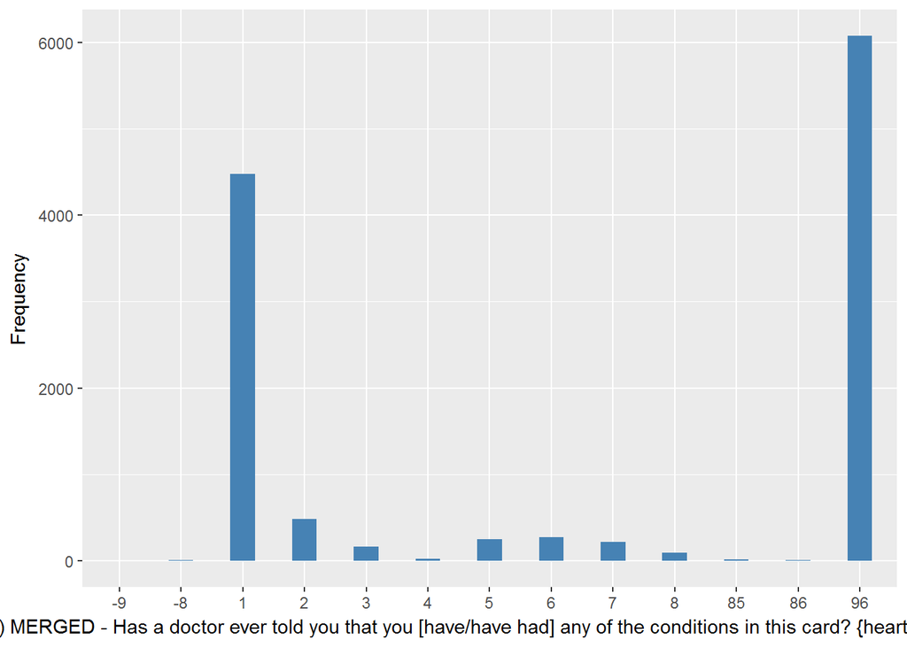

hedim02

| Sample size | Missing values |
| --- | --- |
| 12099 | 9973 |

Category

|  | 2 | 3 | 4 | 5 | 6 | 7 | 8 | 85 | 86 | 96 |
| --- | --- | --- | --- | --- | --- | --- | --- | --- | --- | --- |
| Frequency | 661.00 | 286.00 | 42.00 | 205.00 | 283.00 | 413.00 | 198.00 | 20.00 | 16.00 | 2.00 |
| Percentage | 5.46 | 2.36 | 0.35 | 1.69 | 2.34 | 3.41 | 1.64 | 0.17 | 0.13 | 0.02 |

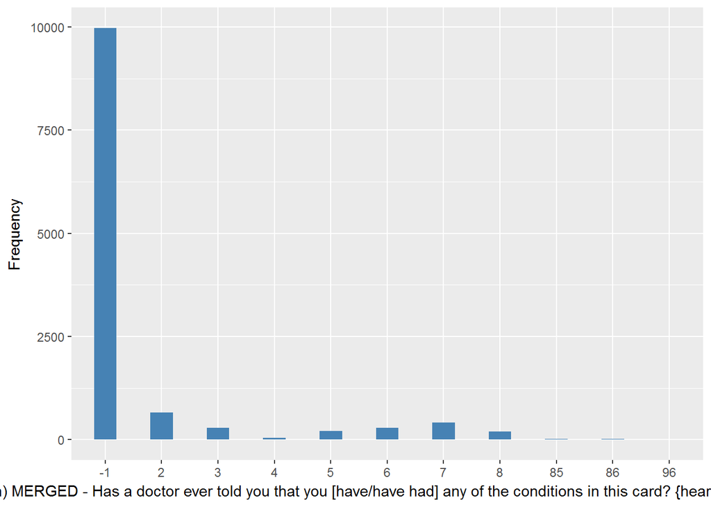

hedim03

| Sample size | Missing values |
| --- | --- |
| 12099 | 11350 |

Category

|  | 3 | 4 | 5 | 6 | 7 | 8 | 85 | 86 | 96 |
| --- | --- | --- | --- | --- | --- | --- | --- | --- | --- |
| Frequency | 248.00 | 26.00 | 69.00 | 117.00 | 151.00 | 112.00 | 19.00 | 6.00 | 1.00 |
| Percentage | 2.05 | 0.21 | 0.57 | 0.97 | 1.25 | 0.93 | 0.16 | 0.05 | 0.01 |

[figure not shown]

hedim04

| Sample size | Missing values |
| --- | --- |
| 12099 | 11837 |

Category

|  | 4 | 5 | 6 | 7 | 8 | 85 |
| --- | --- | --- | --- | --- | --- | --- |
| Frequency | 20.00 | 24.0 | 70.00 | 67.00 | 70.00 | 11.00 |
| Percentage | 0.17 | 0.2 | 0.58 | 0.55 | 0.58 | 0.09 |

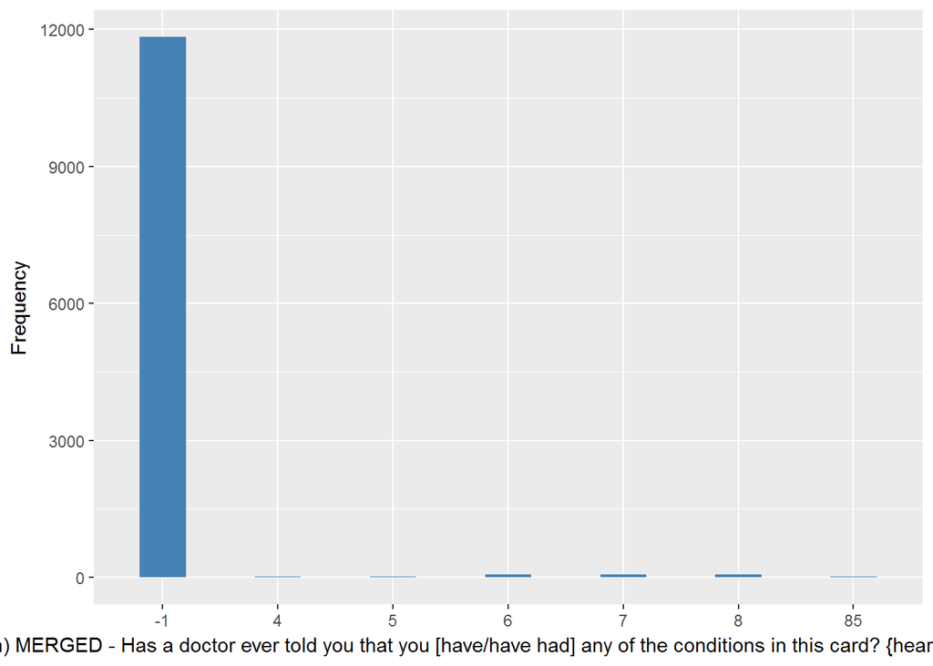

hedim05

| Sample size | Missing values |
| --- | --- |
| 12099 | 12027 |

Category

|  | 5 | 6 | 7 | 8 | 85 | 86 |
| --- | --- | --- | --- | --- | --- | --- |
| Frequency | 9.00 | 12.0 | 16.00 | 32.00 | 2.00 | 1.00 |
| Percentage | 0.07 | 0.1 | 0.13 | 0.26 | 0.02 | 0.01 |

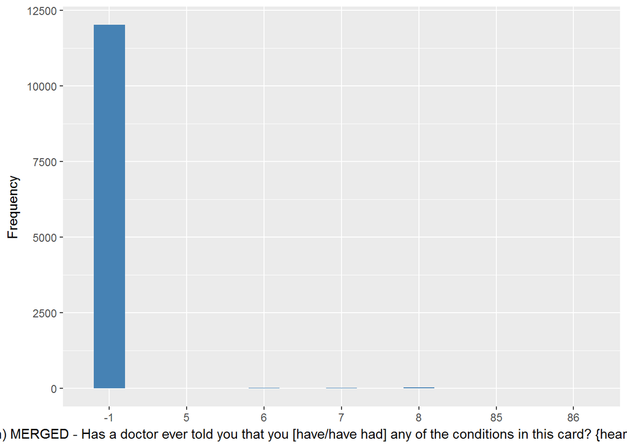

hedim06

| Sample size | Missing values |
| --- | --- |
| 12099 | 12090 |

Category

|  | 6 | 7 | 8 |
| --- | --- | --- | --- |
| Frequency | 5.00 | 1.00 | 3.00 |
| Percentage | 0.04 | 0.01 | 0.02 |

[figure not shown]

hedim07

| Sample size | Missing values |
| --- | --- |
| 12099 | 12096 |

Category

|  | 8 |
| --- | --- |
| Frequency | 3.00 |
| Percentage | 0.02 |

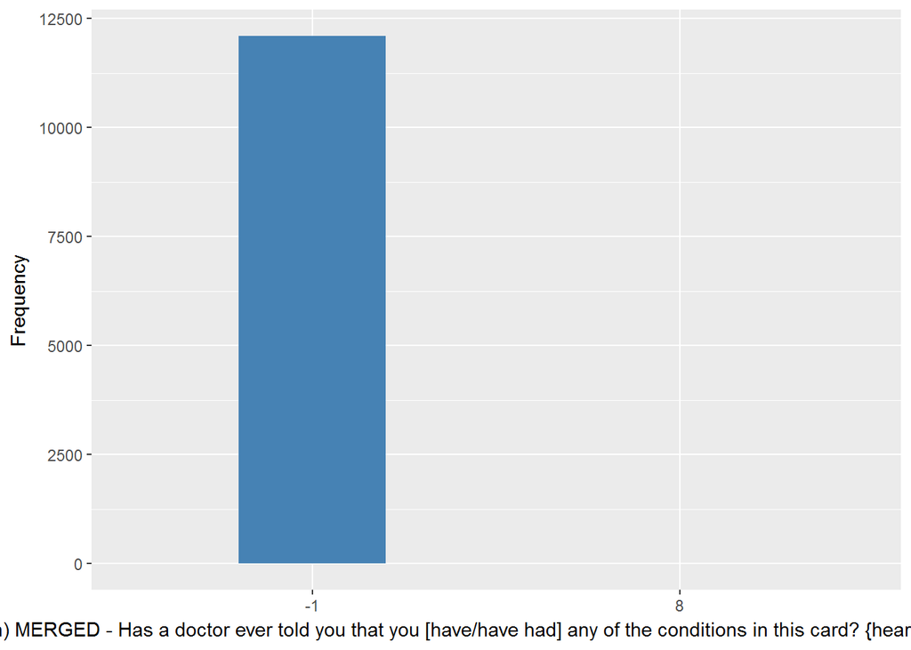

heaga

| Sample size | Missing values |
| --- | --- |
| 12099 | 11292 |

Summary

| Min. | 1st Qu. | Median | Mean | 3rd Qu. | Max. |
| --- | --- | --- | --- | --- | --- |
| 14 | 54 | 60 | 60.82 | 69 | 92 |

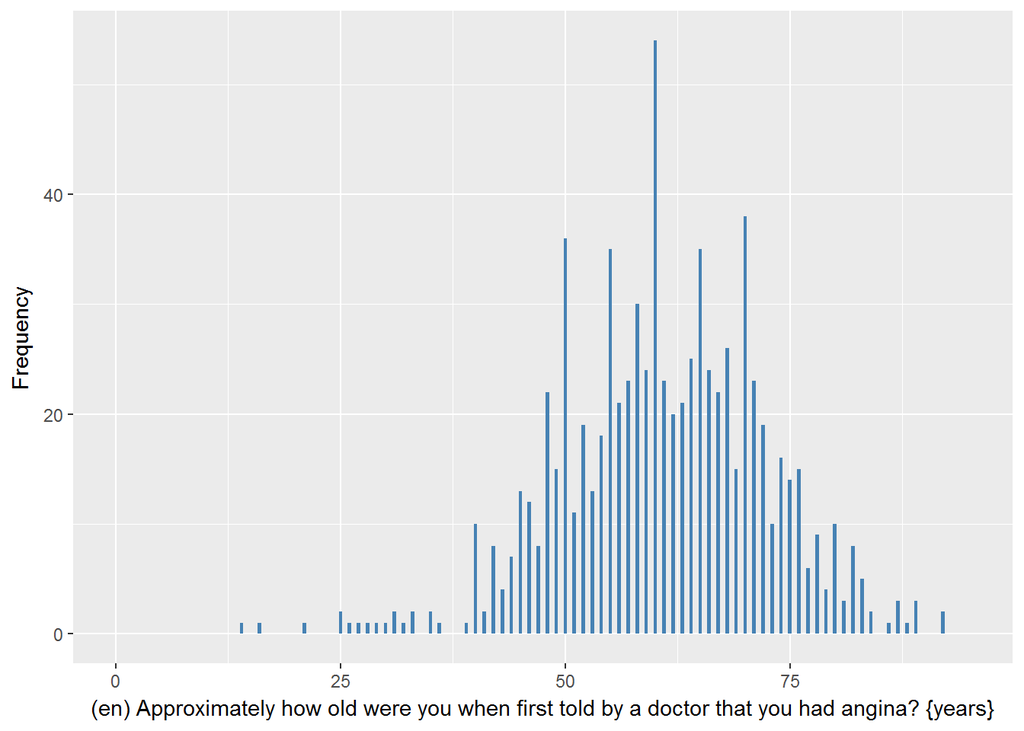

#### 2.1.1.2 Harmonisation algorithm

To compute `h_angina` from the study-specific variable it has to be recoded as follows:

- `some hedimX == 2 into 1`
- `-9 into 997`
- `-8 into 998`
- `otherwise into 0`

To compute `h_angina_age` from the study-specific variable it has to be recoded as follows:

- `if h_angina == 1, h_angina_age = heaga`
- `if h_angina == 0, h_angina_age = 996`
- `-9 into 997`
- `-8 into 998`
- `-1 into 996`
- `otherwise, h_angina_age = 999`

**R script:**

```r
# Categorical variable harmonization
ELSA_ds_w1 <- tibble(id = ELSA_w1$id)
ELSA_ds_w1$h_angina <- rep(0, length(ELSA_w1$id))
ELSA_ds_w1$h_angina[which(ELSA_w1$hedim01 == 2 | ELSA_w1$hedim02 == 2 | ELSA_w1$hedim03 ==
    2 | ELSA_w1$hedim04 == 2 | ELSA_w1$hedim05 == 2 | ELSA_w1$hedim06 == 2 |
    ELSA_w1$hedim07 == 2)] <- 1
ELSA_ds_w1$h_angina[which(ELSA_w1$hedim01 == -9)] <- 997
ELSA_ds_w1$h_angina[which(ELSA_w1$hedim01 == -8)] <- 998

# Continuous variable harmonization
ELSA_ds_w1$h_angina_age <- rep(999, length(ELSA_w1$id))
ELSA_ds_w1$h_angina_age[which(ELSA_ds_w1$h_angina == 0)] <- 996
ELSA_ds_w1$h_angina_age[which(ELSA_ds_w1$h_angina == 1)] <- car::recode(ELSA_w1$heaga[which(ELSA_ds_w1$h_angina ==
    1)], "-1=996;-8=998;-9=997")

# Global table
ELSA_ds <- ELSA_ds_w1
```

#### 2.1.1.3 Statistics of the new harmonized variable

History of angina

| Sample size | Missing values |
| --- | --- |
| 12099 | 9 |

Category

|  | 0 | 1 |
| --- | --- | --- |
| Frequency | 10943.00 | 1147.00 |
| Percentage | 90.45 | 9.48 |

Type of missing

|  | 991 | 992 | 993 | 994 | 995 | 996 | 997 | 998 | 999 | NA |
| --- | --- | --- | --- | --- | --- | --- | --- | --- | --- | --- |
| Frequency | 0 | 0 | 0 | 0 | 0 | 0 | 3.00 | 6.00 | 0 | 0 |
| Percentage | 0 | 0 | 0 | 0 | 0 | 0 | 0.02 | 0.05 | 0 | 0 |

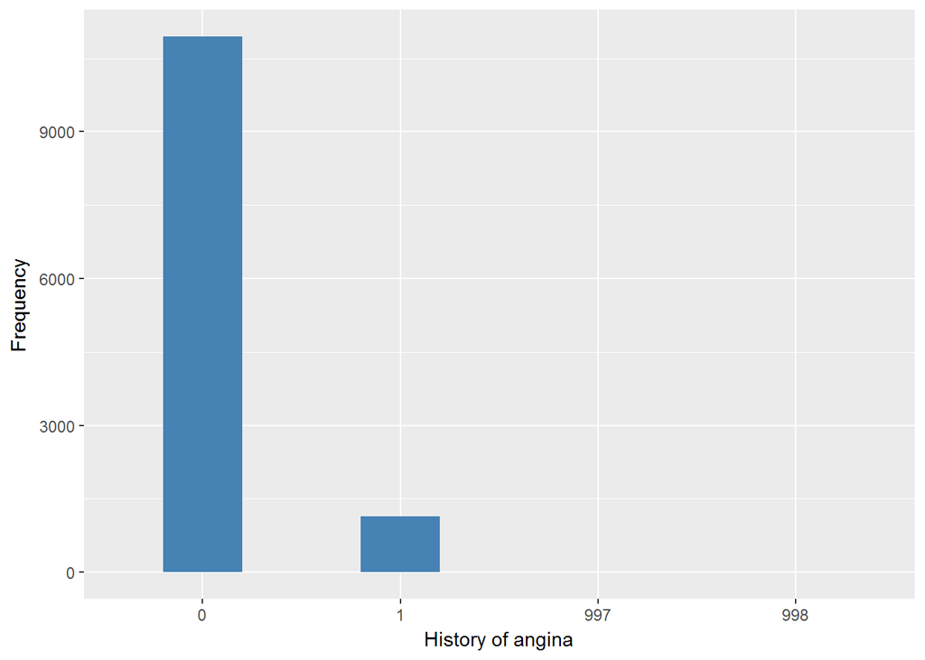

Age first diagnosed angina

| Sample size | Missing values |
| --- | --- |
| 12099 | 11292 |

Values

|  | No-missings | 991 | 992 | 993 | 994 | 995 | 996 | 997 | 998 | 999 | NA |
| --- | --- | --- | --- | --- | --- | --- | --- | --- | --- | --- | --- |
| Frequency | 807.00 | 0 | 0 | 0 | 0 | 0 | 11279.00 | 1.00 | 3.00 | 9.00 | 0 |
| Percentage | 6.67 | 0 | 0 | 0 | 0 | 0 | 93.22 | 0.01 | 0.02 | 0.07 | 0 |

Summary

| Min. | 1st Qu. | Median | Mean | 3rd Qu. | Max. |
| --- | --- | --- | --- | --- | --- |
| 14 | 54 | 60 | 60.82 | 69 | 92 |

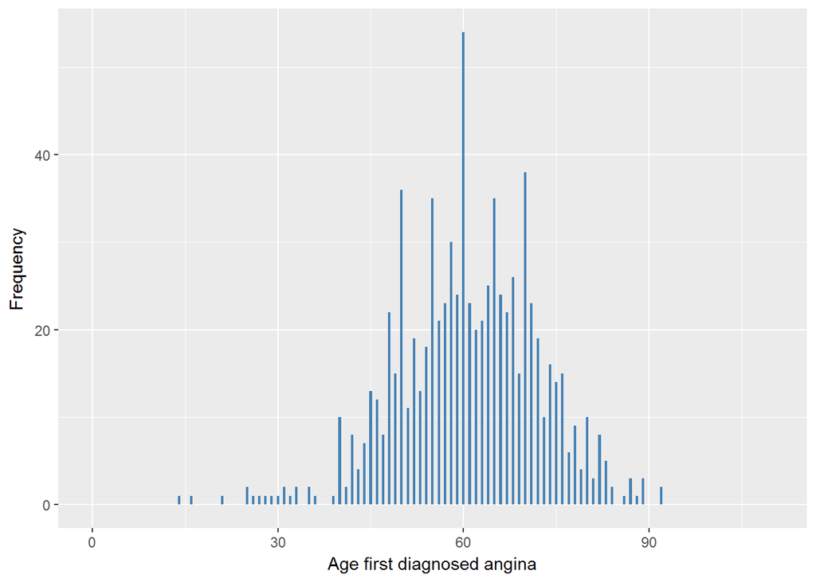

#### 2.1.1.4 Validation

|  | hedimX!=2->0 | hedimX==2->1 | hedimX==-9->997 | hedimX==-8->998 |
| --- | --- | --- | --- | --- |
| BeforeH | 10943 | 1147 | 3 | 6 |
| AfterH | 10943 | 1147 | 3 | 6 |

### 2.1.2 Wave 2

#### 2.1.2.1 Study-specific variable description

| **Name** | `hedim01` | `hedim02` | `hedim03` | `hedim04` | `hedim05` | `hedim06` | `hedim07` | `hedim08` | `hedia01` | `HeAga` |
| --- | --- | --- | --- | --- | --- | --- | --- | --- | --- | --- |
| **Label** | `Diagnosed cardiovascular condit. newly reported at W2 (1st mention) (merged var)` | `Diagnosed cardiovascular condit. newly reported at W2 (2nd mention) (merged var)` | `Diagnosed cardiovascular condit. newly reported at W2 (3rd mention) (merged var)` | `Diagnosed cardiovascular condit. newly reported at W2 (4th mention) (merged var)` | `Diagnosed cardiovascular condit. newly reported at W2 (5th mention) (merged var)` | `Diagnosed cardiovascular condit. newly reported at W2 (6th mention) (merged var)` | `Diagnosed cardiovascular condit. newly reported at W2 (7th mention) (merged var)` | `Diagnosed cardiovascular condit. newly reported at W2 (8th mention) (merged var)` | `Diagnosed cardiovascular condition newly reported at W2 (1st mention)` | `Age first told had angina` |
| **Table name** | `wave_2_core_data_v4` | `wave_2_core_data_v4` | `wave_2_core_data_v4` | `wave_2_core_data_v4` | `wave_2_core_data_v4` | `wave_2_core_data_v4` | `wave_2_core_data_v4` | `wave_2_core_data_v4` | `wave_2_core_data_v4` | `wave_2_core_data_v4` |
| **Categories** | `1 = High blood pressure or hypertension` `2 = Angina` `3 = A heart attack (including myocardial infarction or coronary)` `4 = Congestive heart failure` `5 = A heart murmur` `6 = An abnormal heart rhy… | `1 = High blood pressure or hypertension` `2 = Angina` `3 = A heart attack (including myocardial infarction or coronary)` `4 = Congestive heart failure` `5 = A heart murmur` `6 = An abnormal heart rhy… | `1 = High blood pressure or hypertension` `2 = Angina` `3 = A heart attack (including myocardial infarction or coronary)` `4 = Congestive heart failure` `5 = A heart murmur` `6 = An abnormal heart rhy… | `1 = High blood pressure or hypertension` `2 = Angina` `3 = A heart attack (including myocardial infarction or coronary)` `4 = Congestive heart failure` `5 = A heart murmur` `6 = An abnormal heart rhy… | `1 = High blood pressure or hypertension` `2 = Angina` `3 = A heart attack (including myocardial infarction or coronary)` `4 = Congestive heart failure` `5 = A heart murmur` `6 = An abnormal heart rhy… | `1 = High blood pressure or hypertension` `2 = Angina` `3 = A heart attack (including myocardial infarction or coronary)` `4 = Congestive heart failure` `5 = A heart murmur` `6 = An abnormal heart rhy… | `1 = High blood pressure or hypertension` `2 = Angina` `3 = A heart attack (including myocardial infarction or coronary)` `4 = Congestive heart failure` `5 = A heart murmur` `6 = An abnormal heart rhy… | `1 = High blood pressure or hypertension` `2 = Angina` `3 = A heart attack (including myocardial infarction or coronary)` `4 = Congestive heart failure` `5 = A heart murmur` `6 = An abnormal heart rhy… | `1 = High blood pressure or hypertension` `2 = Angina` `3 = A heart attack (including myocardial infarction or coronary)` `4 = Congestive heart failure` `5 = A heart murmur` `6 = An abnormal heart rhy… | `continuous` |
| **Missings** | `-9 = Refusal` `-8 = Don't know` `-1 = Not applicable` | `-9 = Refusal` `-8 = Don't know` `-1 = Not applicable` | `-9 = Refusal` `-8 = Don't know` `-1 = Not applicable` | `-9 = Refusal` `-8 = Don't know` `-1 = Not applicable` | `-9 = Refusal` `-8 = Don't know` `-1 = Not applicable` | `-9 = Refusal` `-8 = Don't know` `-1 = Not applicable` | `-9 = Refusal` `-8 = Don't know` `-1 = Not applicable` | `-9 = Refusal` `-8 = Don't know` `-1 = Not applicable` | `-9 = Refusal` `-8 = Don't know` `-1 = Not applicable` | `-9 = Refusal` `-8 = Don't know` `-1 = Not applicable` |
| **Description** |  |  |  |  |  |  |  |  |  |  |

hedim01

| Sample size | Missing values |
| --- | --- |
| 9432 | 9 |

Category

|  | 1 | 2 | 3 | 4 | 5 | 6 | 7 | 8 | 9 | 51 | 52 | 85 | 86 | 96 |
| --- | --- | --- | --- | --- | --- | --- | --- | --- | --- | --- | --- | --- | --- | --- |
| Frequency | 1707.0 | 213.00 | 59.00 | 14.00 | 91.00 | 196.00 | 171.00 | 76.00 | 946.00 | 6.00 | 7.00 | 27.00 | 8.00 | 5902.00 |
| Percentage | 18.1 | 2.26 | 0.63 | 0.15 | 0.96 | 2.08 | 1.81 | 0.81 | 10.03 | 0.06 | 0.07 | 0.29 | 0.08 | 62.57 |

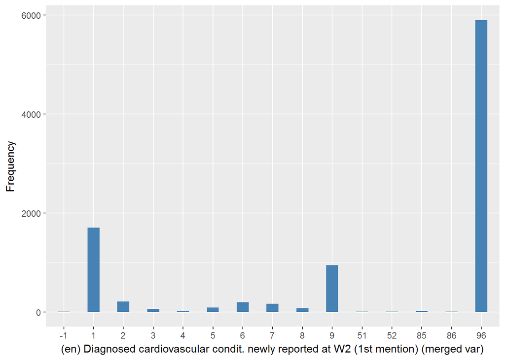

hedim02

| Sample size | Missing values |
| --- | --- |
| 9432 | 8262 |

Category

|  | 2 | 3 | 4 | 5 | 6 | 7 | 8 | 9 | 51 | 52 | 85 | 86 |
| --- | --- | --- | --- | --- | --- | --- | --- | --- | --- | --- | --- | --- |
| Frequency | 148.00 | 51.00 | 7.00 | 59.00 | 110.00 | 151.0 | 63.00 | 546.00 | 8.00 | 4.00 | 18.00 | 5.00 |
| Percentage | 1.57 | 0.54 | 0.07 | 0.63 | 1.17 | 1.6 | 0.67 | 5.79 | 0.08 | 0.04 | 0.19 | 0.05 |

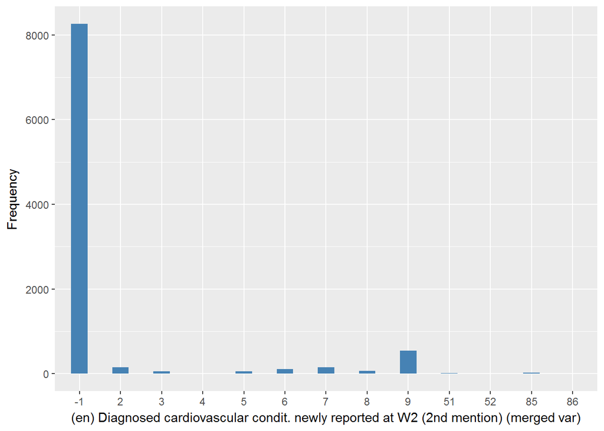

hedim03

| Sample size | Missing values |
| --- | --- |
| 9432 | 9078 |

Category

|  | 3 | 4 | 5 | 6 | 7 | 8 | 9 | 51 | 52 | 85 |
| --- | --- | --- | --- | --- | --- | --- | --- | --- | --- | --- |
| Frequency | 22.00 | 3.00 | 17.00 | 31.00 | 54.00 | 24.00 | 175.00 | 8.00 | 7.00 | 13.00 |
| Percentage | 0.23 | 0.03 | 0.18 | 0.33 | 0.57 | 0.25 | 1.86 | 0.08 | 0.07 | 0.14 |

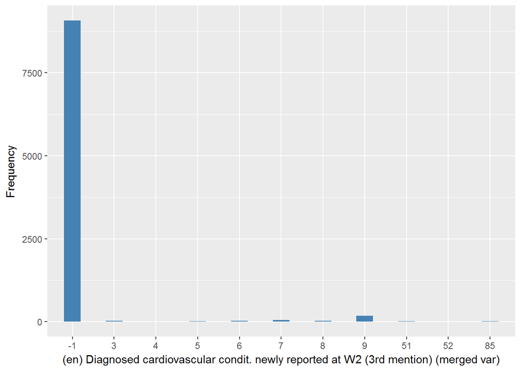

hedim04

| Sample size | Missing values |
| --- | --- |
| 9432 | 9336 |

Category

|  | 4 | 5 | 6 | 7 | 8 | 9 | 51 | 52 | 85 |
| --- | --- | --- | --- | --- | --- | --- | --- | --- | --- |
| Frequency | 2.00 | 3.00 | 3.00 | 8.00 | 6.00 | 60.00 | 7.00 | 4.00 | 3.00 |
| Percentage | 0.02 | 0.03 | 0.03 | 0.08 | 0.06 | 0.64 | 0.07 | 0.04 | 0.03 |

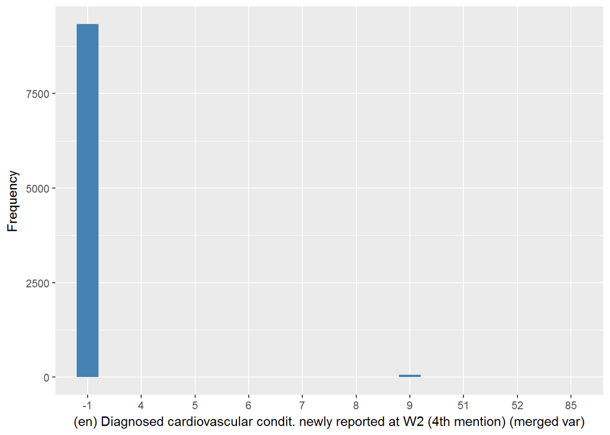

hedim05

| Sample size | Missing values |
| --- | --- |
| 9432 | 9414 |

Category

|  | 6 | 8 | 9 | 51 | 52 | 85 |
| --- | --- | --- | --- | --- | --- | --- |
| Frequency | 3.00 | 1.00 | 10.00 | 2.00 | 1.00 | 1.00 |
| Percentage | 0.03 | 0.01 | 0.11 | 0.02 | 0.01 | 0.01 |

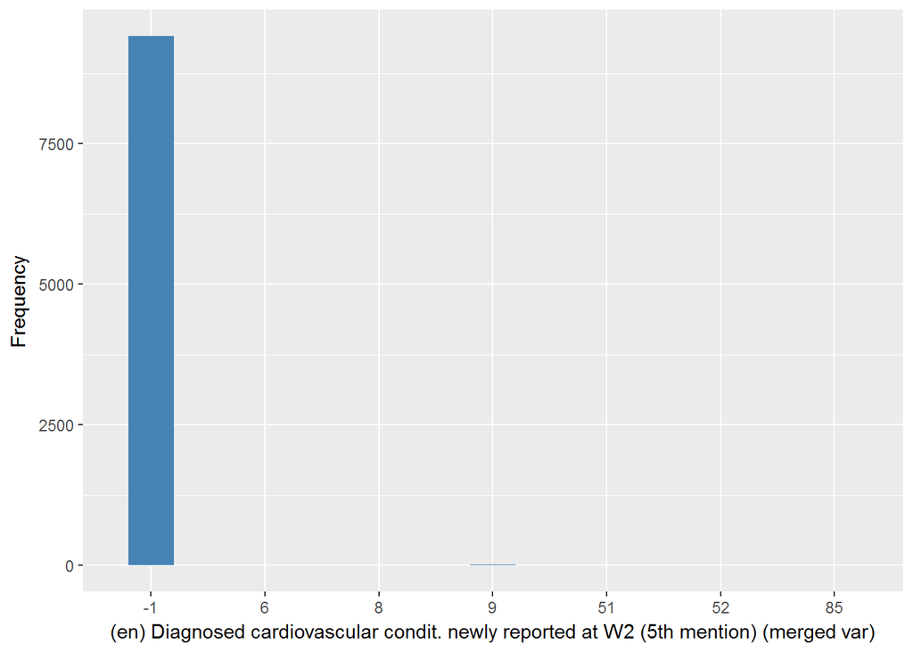

hedim06

| Sample size | Missing values |
| --- | --- |
| 9432 | 9427 |

Category

|  | 7 | 9 | 52 |
| --- | --- | --- | --- |
| Frequency | 1.00 | 3.00 | 1.00 |
| Percentage | 0.01 | 0.03 | 0.01 |

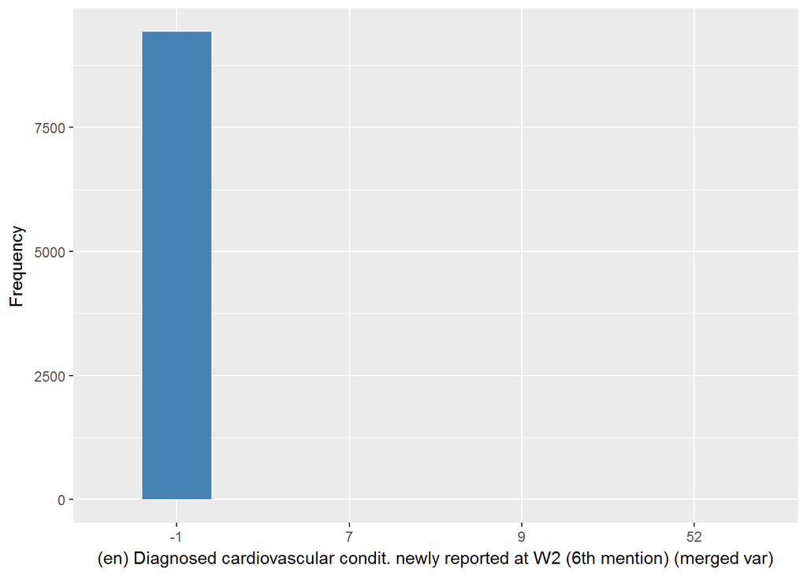

hedim07

| Sample size | Missing values |
| --- | --- |
| 9432 | 9431 |

Category

|  | 9 |
| --- | --- |
| Frequency | 1.00 |
| Percentage | 0.01 |

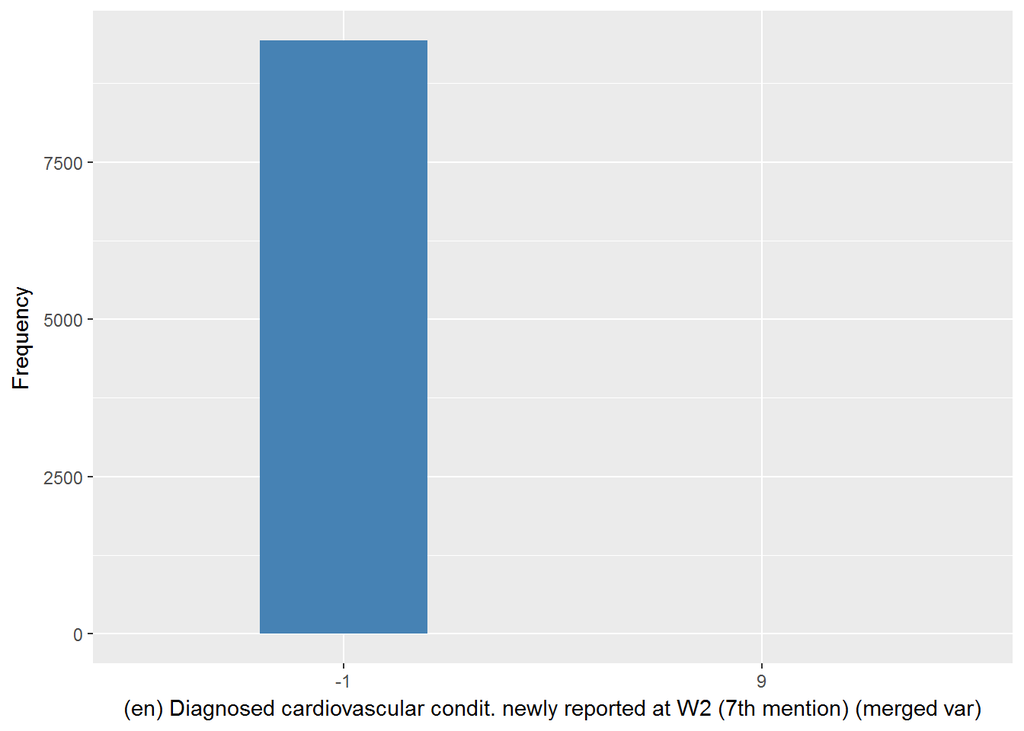

hedim08

| Sample size | Missing values |
| --- | --- |
| 9432 | 9431 |

Category

|  | 52 |
| --- | --- |
| Frequency | 1.00 |
| Percentage | 0.01 |

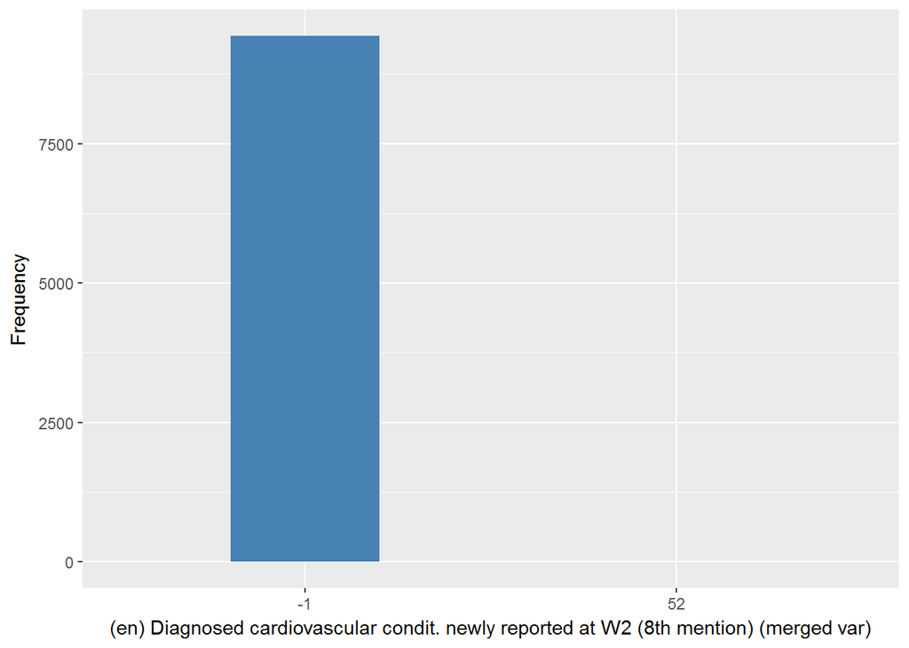

hedia01

| Sample size | Missing values |
| --- | --- |
| 9432 | 9 |

Category

|  | 1 | 2 | 3 | 4 | 5 | 6 | 7 | 8 | 9 | 95 | 96 |
| --- | --- | --- | --- | --- | --- | --- | --- | --- | --- | --- | --- |
| Frequency | 1634.00 | 204.00 | 64.00 | 11.00 | 81.00 | 175.00 | 178.00 | 86.00 | 997.00 | 91.00 | 5902.00 |
| Percentage | 17.32 | 2.16 | 0.68 | 0.12 | 0.86 | 1.86 | 1.89 | 0.91 | 10.57 | 0.96 | 62.57 |

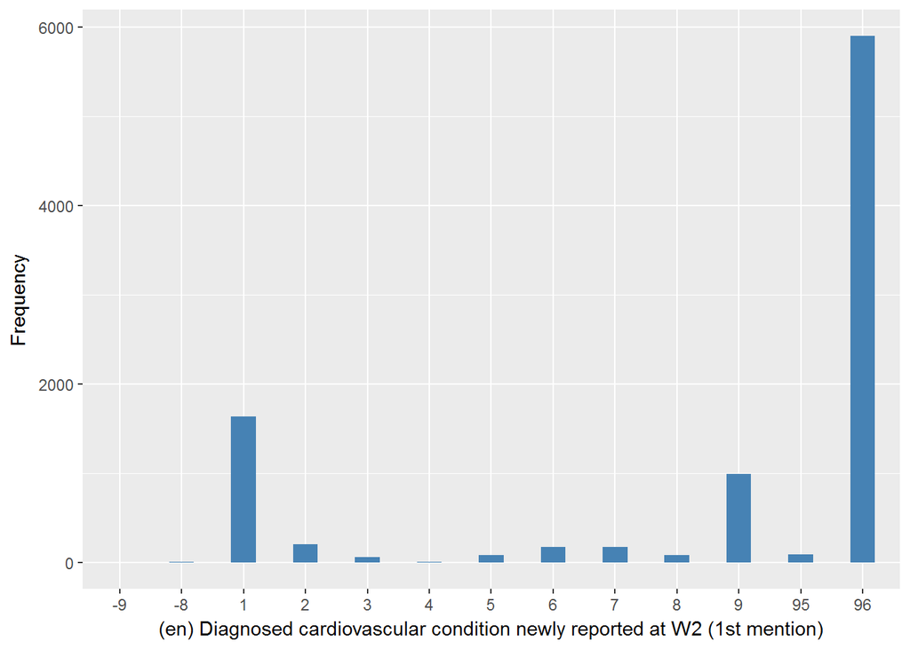

HeAga

| Sample size | Missing values |
| --- | --- |
| 9432 | 9426 |

Summary

| Min. | 1st Qu. | Median | Mean | 3rd Qu. | Max. |
| --- | --- | --- | --- | --- | --- |
| 39 | 42.75 | 47.5 | 52.67 | 57.5 | 80 |

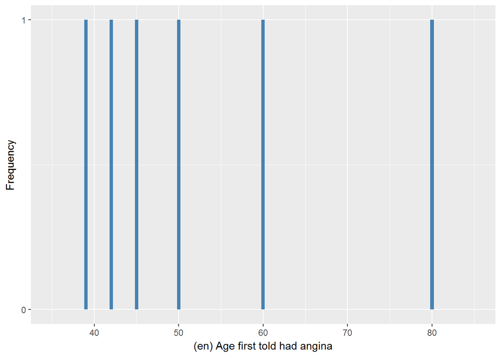

#### 2.1.2.2 Harmonisation algorithm

To compute `h_angina` from the study-specific variable it has to be recoded as follows:

- `h_angina w1 == 1 or some hedimX == 2 into 1`
- `h_angina w1 != 1 and hedia01 == -9 and hedimX == -1 into 997`
- `h_angina w1 != 1 and hedia01 == -8 and hedimX == -1 into 998`
- `otherwise into 0`

To compute `h_angina_age` from the study-specific variable it has to be recoded as follows:

- `if h_angina == 1, h_angina_age = HeAga`
- `if h_angina == 0, h_angina_age = 996`
- `-9 into 997`
- `-8 into 998`
- `-1 into 996`
- `otherwise, h_angina_age = 999`

**R script:**

```r
ELSA_w2 <- left_join(ELSA_w2, ELSA_ds, by = "id")

# Categorical variable harmonization
ELSA_ds_w2 <- tibble(id = ELSA_w2$id)
ELSA_ds_w2$h_angina <- rep(0, length(ELSA_w2$id))
ELSA_ds_w2$h_angina[which(ELSA_w2$h_angina == 1 | ELSA_w2$hedim01 == 2 | ELSA_w2$hedim02 ==
    2 | ELSA_w2$hedim03 == 2 | ELSA_w2$hedim04 == 2 | ELSA_w2$hedim05 == 2 |
    ELSA_w2$hedim06 == 2 | ELSA_w2$hedim07 == 2 | ELSA_w2$hedim08 == 2)] <- 1
ELSA_ds_w2$h_angina[which((ELSA_w2$h_angina != 1 | is.na(ELSA_w2$h_angina)) &
    ELSA_w2$hedia01 == -9 & ELSA_w2$hedim01 == -1)] <- 997
ELSA_ds_w2$h_angina[which((ELSA_w2$h_angina != 1 | is.na(ELSA_w2$h_angina)) &
    ELSA_w2$hedia01 == -8 & ELSA_w2$hedim01 == -1)] <- 998

# Continuous variable harmonization
ELSA_ds_w2$h_angina_age <- rep(999, length(ELSA_w2$id))
ELSA_ds_w2$h_angina_age[which(ELSA_ds_w2$h_angina == 0)] <- 996
ELSA_ds_w2$h_angina_age[which(ELSA_ds_w2$h_angina == 1)] <- car::recode(ELSA_w2$HeAga[which(ELSA_ds_w2$h_angina ==
    1)], "-1=996;-8=998;-9=997")
ELSA_ds_w2$h_angina_age[which(ELSA_ds_w2$h_angina == 1 & !is.na(ELSA_w2$h_angina_age) &
    !ELSA_w2$h_angina_age %in% miss_values_vector)] <- ELSA_w2$h_angina_age[which(ELSA_ds_w2$h_angina ==
    1 & !is.na(ELSA_w2$h_angina_age) & !ELSA_w2$h_angina_age %in% miss_values_vector)]

# Update of global table
assign_merge <- function(endtib, sttib, log_vec = c(T), col_end_index = NULL,
    col_st_index = NULL) {
    newtib <- full_join(endtib, sttib, by = "id")
    row.names(newtib) <- newtib$id
    newtib[log_vec, col_end_index] <- newtib[log_vec, col_st_index]
    id_ind <- match("id", names(newtib))
    newtib <- newtib[, c(id_ind, col_end_index)]
    names(newtib)[2] <- "x"
    newtib$x <- car::recode(newtib$x, "NA=999")
    names(newtib)[2] <- names(endtib)[col_end_index]
    newtib
}
ELSA_ds_prov <- ELSA_ds[, c(1, 2)]
ELSA_ds_prov <- assign_merge(ELSA_ds_prov, ELSA_ds_w2, log_vec = ELSA_ds_w2$id,
    col_end_index = 2, col_st_index = 3)
ELSA_ds_aux <- ELSA_ds[, c(1, 3)]
ELSA_ds_aux <- assign_merge(ELSA_ds_aux, ELSA_ds_w2, log_vec = ELSA_ds_w2$id[which(ELSA_ds_w2$h_angina !=
    999)], col_end_index = 2, col_st_index = 4)
ELSA_ds <- ELSA_ds_prov
ELSA_ds$h_angina_age <- ELSA_ds_aux$h_angina_age
rm(ELSA_ds_prov)
rm(ELSA_ds_aux)
```

#### 2.1.2.3 Statistics of the new harmonized variable

History of angina

| Sample size | Missing values |
| --- | --- |
| 9432 | 7 |

Category

|  | 0 | 1 |
| --- | --- | --- |
| Frequency | 8446.00 | 979.00 |
| Percentage | 89.55 | 10.38 |

Type of missing

|  | 991 | 992 | 993 | 994 | 995 | 996 | 997 | 998 | 999 | NA |
| --- | --- | --- | --- | --- | --- | --- | --- | --- | --- | --- |
| Frequency | 0 | 0 | 0 | 0 | 0 | 0 | 1.00 | 6.00 | 0 | 0 |
| Percentage | 0 | 0 | 0 | 0 | 0 | 0 | 0.01 | 0.06 | 0 | 0 |

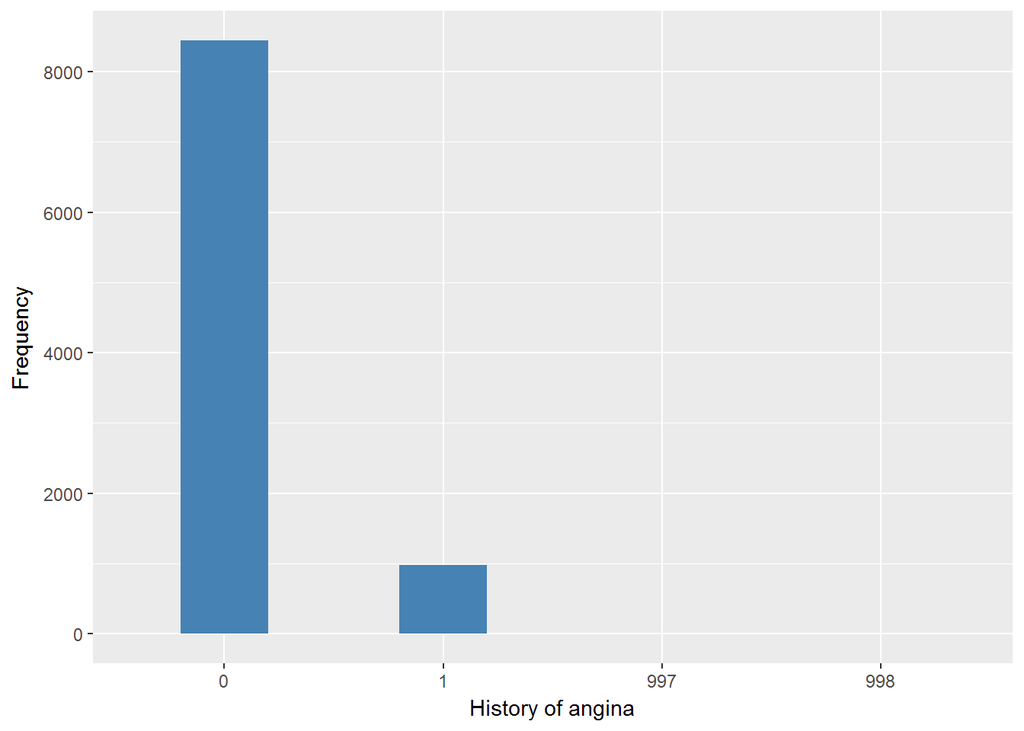

Age first diagnosed angina

| Sample size | Missing values |
| --- | --- |
| 9432 | 8841 |

Values

|  | No-missings | 991 | 992 | 993 | 994 | 995 | 996 | 997 | 998 | 999 | NA |
| --- | --- | --- | --- | --- | --- | --- | --- | --- | --- | --- | --- |
| Frequency | 591.00 | 0 | 0 | 0 | 0 | 0 | 8834.00 | 0 | 0 | 7.00 | 0 |
| Percentage | 6.27 | 0 | 0 | 0 | 0 | 0 | 93.66 | 0 | 0 | 0.07 | 0 |

Summary

| Min. | 1st Qu. | Median | Mean | 3rd Qu. | Max. |
| --- | --- | --- | --- | --- | --- |
| 16 | 52.5 | 60 | 60.16 | 68 | 92 |

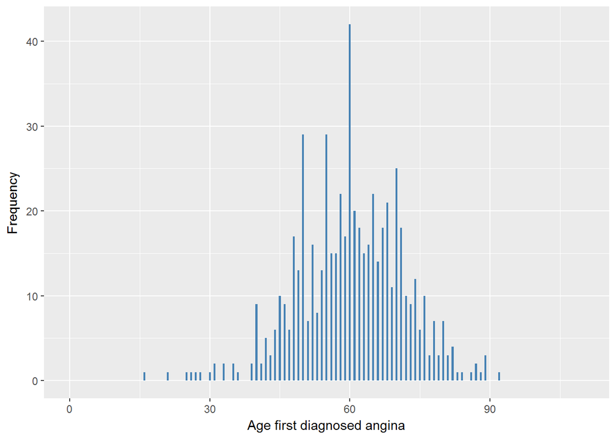

#### 2.1.2.4 Validation

|  | hedimX!=2->0 | hedimX==2->1 | hedimX==-9->997 | hedimX==-8->998 |
| --- | --- | --- | --- | --- |
| BeforeH | 8446 | 979 | 1 | 6 |
| AfterH | 8446 | 979 | 1 | 6 |

### 2.1.3 Wave 3

#### 2.1.3.1 Study-specific variable description

| **Name** | `dhediman` | `heaga` |
| --- | --- | --- |
| **Label** | `CVD: angina diagnosis newly reported (merged)` | `Age first told had angina` |
| **Table name** | `wave_3_elsa_data_v4` | `wave_3_elsa_data_v4` |
| **Categories** | `1 = Mentioned` `0 = Not mentioned` | `continuous` |
| **Missings** | `-9 = Refusal` `-8 = Don't know` `-1 = Not applicable` | `-9 = Refusal` `-8 = Don't know` `-1 = Not applicable` |
| **Description** |  |  |

dhediman

| Sample size | Missing values |
| --- | --- |
| 9771 | 5 |

Category

|  | 0 | 1 |
| --- | --- | --- |
| Frequency | 9641.00 | 125.00 |
| Percentage | 98.67 | 1.28 |

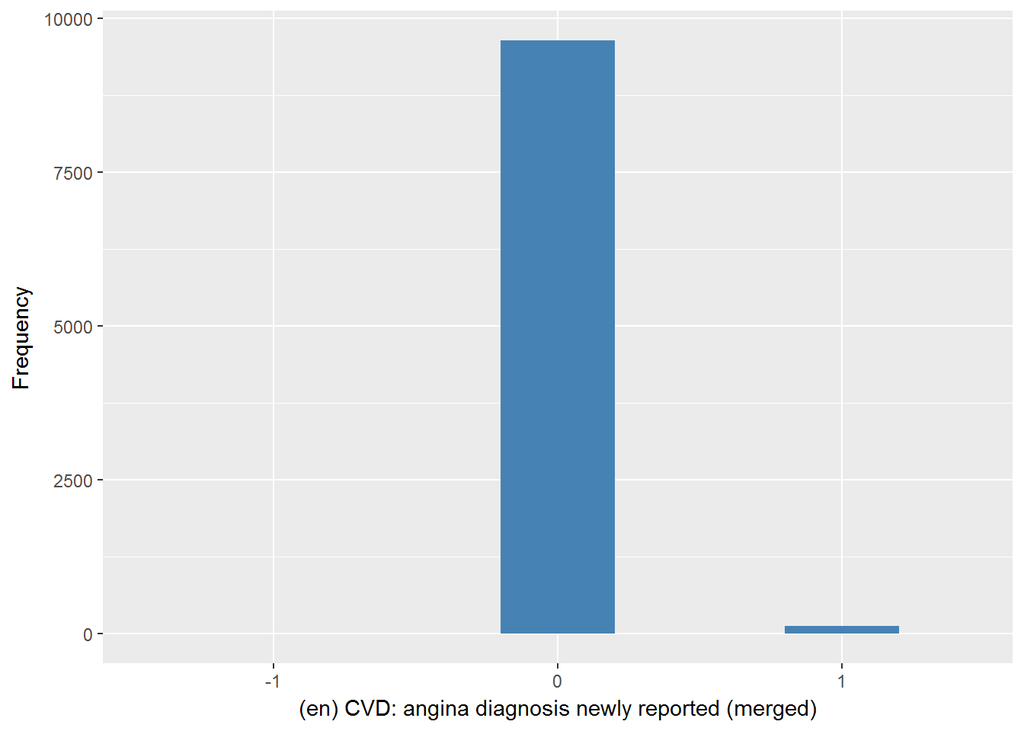

heaga

| Sample size | Missing values |
| --- | --- |
| 9771 | 9736 |

Summary

| Min. | 1st Qu. | Median | Mean | 3rd Qu. | Max. |
| --- | --- | --- | --- | --- | --- |
| 30 | 44.5 | 50 | 48.57 | 51.5 | 66 |

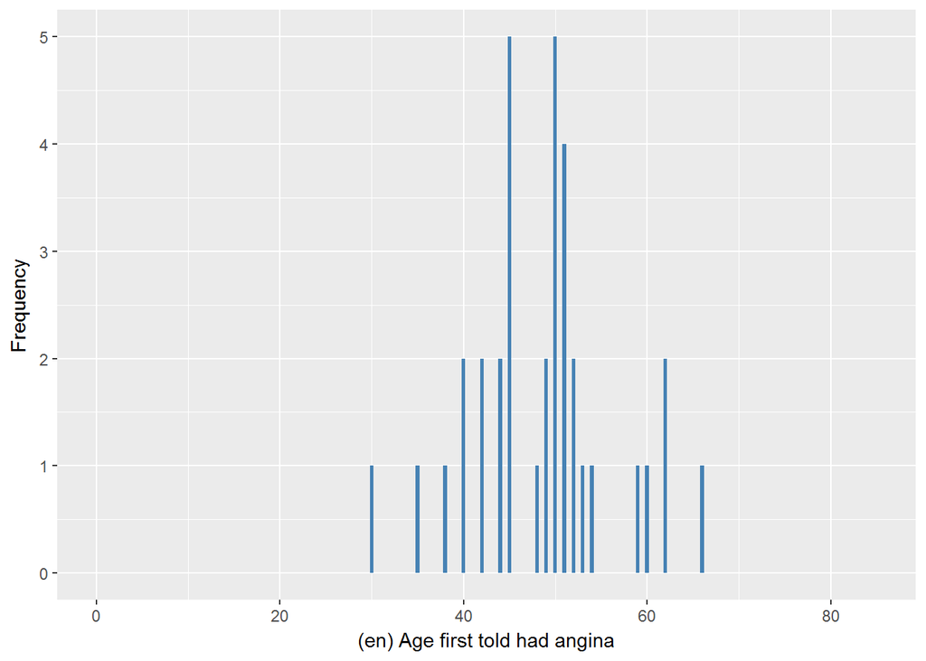

#### 2.1.3.2 Harmonisation algorithm

To compute `h_angina` from the study-specific variable it has to be recoded as follows:

- `h_angina previous == 1 or dhediman == 1 into 1`
- `h_angina previous != 1 and dhediman == 0 into 0`
- `dhediman == -1 and h_angina previous != 1 into 996`

To compute `h_angina_age` from the study-specific variable it has to be recoded as follows:

- `if h_angina == 1, h_angina_age = heaga`
- `if h_angina == 0, h_angina_age = 996`
- `-9 into 997`
- `-8 into 998`
- `-1 into 996`
- `otherwise, h_angina_age = 999`

**R script:**

```r
ELSA_w3 <- left_join(ELSA_w3, ELSA_ds, by = "id")

# Categorical variable harmonization
ELSA_ds_w3 <- tibble(id = ELSA_w3$id)
ELSA_ds_w3$h_angina <- rep(999, length(ELSA_w3$id))
ELSA_ds_w3$h_angina[which(ELSA_w3$h_angina == 1 | ELSA_w3$dhediman == 1)] <- 1
ELSA_ds_w3$h_angina[which((ELSA_w3$h_angina != 1 | is.na(ELSA_w3$h_angina)) &
    ELSA_w3$dhediman == 0)] <- 0
ELSA_ds_w3$h_angina[which((ELSA_w3$h_angina != 1 | is.na(ELSA_w3$h_angina)) &
    ELSA_w3$dhediman == -1)] <- 996

# Continuous variable harmonization
ELSA_ds_w3$h_angina_age <- rep(999, length(ELSA_w3$id))
ELSA_ds_w3$h_angina_age[which(ELSA_ds_w3$h_angina == 0)] <- 996
ELSA_ds_w3$h_angina_age[which(ELSA_ds_w3$h_angina == 1)] <- car::recode(ELSA_w3$heaga[which(ELSA_ds_w3$h_angina ==
    1)], "-1=996;-8=998;-9=997")
ELSA_ds_w3$h_angina_age[which(ELSA_ds_w3$h_angina == 1 & !is.na(ELSA_w3$h_angina_age) &
    !ELSA_w3$h_angina_age %in% miss_values_vector)] <- ELSA_w3$h_angina_age[which(ELSA_ds_w3$h_angina ==
    1 & !is.na(ELSA_w3$h_angina_age) & !ELSA_w3$h_angina_age %in% miss_values_vector)]

# Update of global table
assign_merge <- function(endtib, sttib, log_vec = c(T), col_end_index = NULL,
    col_st_index = NULL) {
    newtib <- full_join(endtib, sttib, by = "id")
    row.names(newtib) <- newtib$id
    newtib[log_vec, col_end_index] <- newtib[log_vec, col_st_index]
    id_ind <- match("id", names(newtib))
    newtib <- newtib[, c(id_ind, col_end_index)]
    names(newtib)[2] <- "x"
    newtib$x <- car::recode(newtib$x, "NA=999")
    names(newtib)[2] <- names(endtib)[col_end_index]
    newtib
}
ELSA_ds_prov <- ELSA_ds[, c(1, 2)]
ELSA_ds_prov <- assign_merge(ELSA_ds_prov, ELSA_ds_w3, log_vec = ELSA_ds_w3$id,
    col_end_index = 2, col_st_index = 3)
ELSA_ds_aux <- ELSA_ds[, c(1, 3)]
ELSA_ds_aux <- assign_merge(ELSA_ds_aux, ELSA_ds_w3, log_vec = ELSA_ds_w3$id[which(ELSA_ds_w3$h_angina !=
    999)], col_end_index = 2, col_st_index = 4)
ELSA_ds <- ELSA_ds_prov
ELSA_ds$h_angina_age <- ELSA_ds_aux$h_angina_age
rm(ELSA_ds_prov)
rm(ELSA_ds_aux)
```

#### 2.1.3.3 Statistics of the new harmonized variable

History of angina

| Sample size | Missing values |
| --- | --- |
| 9771 | 5 |

Category

|  | 0 | 1 |
| --- | --- | --- |
| Frequency | 8859.00 | 907.00 |
| Percentage | 90.67 | 9.28 |

Type of missing

|  | 991 | 992 | 993 | 994 | 995 | 996 | 997 | 998 | 999 | NA |
| --- | --- | --- | --- | --- | --- | --- | --- | --- | --- | --- |
| Frequency | 0 | 0 | 0 | 0 | 0 | 5.00 | 0 | 0 | 0 | 0 |
| Percentage | 0 | 0 | 0 | 0 | 0 | 0.05 | 0 | 0 | 0 | 0 |

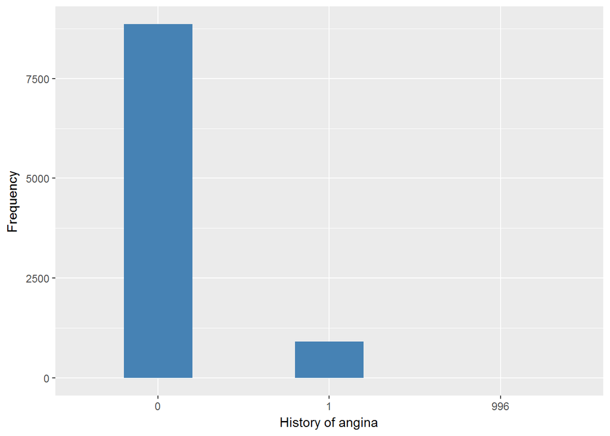

Age first diagnosed angina

| Sample size | Missing values |
| --- | --- |
| 9771 | 9251 |

Values

|  | No-missings | 991 | 992 | 993 | 994 | 995 | 996 | 997 | 998 | 999 | NA |
| --- | --- | --- | --- | --- | --- | --- | --- | --- | --- | --- | --- |
| Frequency | 520.00 | 0 | 0 | 0 | 0 | 0 | 9245.00 | 0 | 1.00 | 5.00 | 0 |
| Percentage | 5.32 | 0 | 0 | 0 | 0 | 0 | 94.62 | 0 | 0.01 | 0.05 | 0 |

Summary

| Min. | 1st Qu. | Median | Mean | 3rd Qu. | Max. |
| --- | --- | --- | --- | --- | --- |
| 21 | 51 | 60 | 59.35 | 67 | 92 |

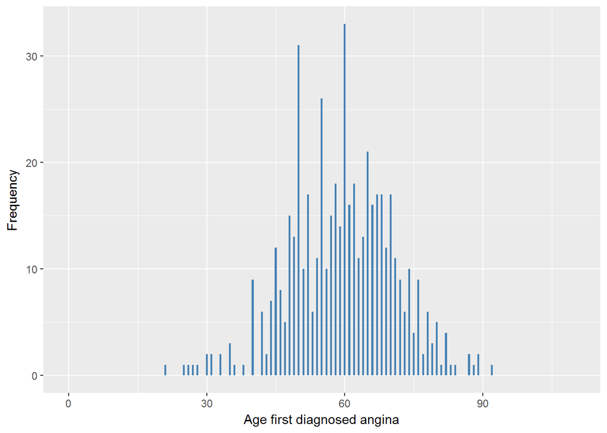

#### 2.1.3.4 Validation

|  | dhediman==0->0 | dhediman==1->1 | dhediman==-1->996 |
| --- | --- | --- | --- |
| BeforeH | 8859 | 907 | 5 |
| AfterH | 8859 | 907 | 5 |

### 2.1.4 Wave 4

#### 2.1.4.1 Study-specific variable description

| **Name** | `hediman` | `heaga` |
| --- | --- | --- |
| **Label** | `CVD: angina diagnosis newly reported (merged)` | `Age first told had angina` |
| **Table name** | `wave_4_elsa_data_v3` | `wave_4_elsa_data_v3` |
| **Categories** | `1 = Mentioned` `0 = Not mentioned` | `continuous` |
| **Missings** | `-9 = Refusal` `-8 = Don't know` `-1 = Not applicable` | `-9 = Refusal` `-8 = Don't know` `-2 = Capi/Interview Error` `-1 = Not applicable` |
| **Description** |  |  |

hediman

| Sample size | Missing values |
| --- | --- |
| 11050 | 16 |

Category

|  | 0 | 1 |
| --- | --- | --- |
| Frequency | 10795.00 | 239.00 |
| Percentage | 97.69 | 2.16 |

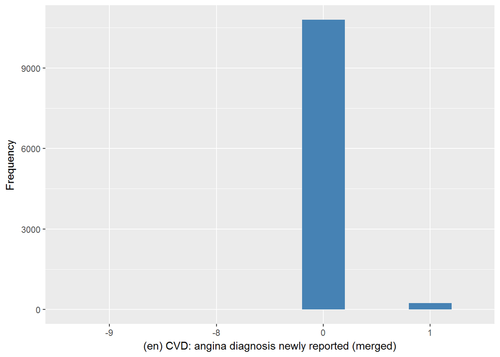

heaga

| Sample size | Missing values |
| --- | --- |
| 11050 | 10907 |

Summary

| Min. | 1st Qu. | Median | Mean | 3rd Qu. | Max. |
| --- | --- | --- | --- | --- | --- |
| 8 | 50 | 58 | 58.59 | 67 | 86 |

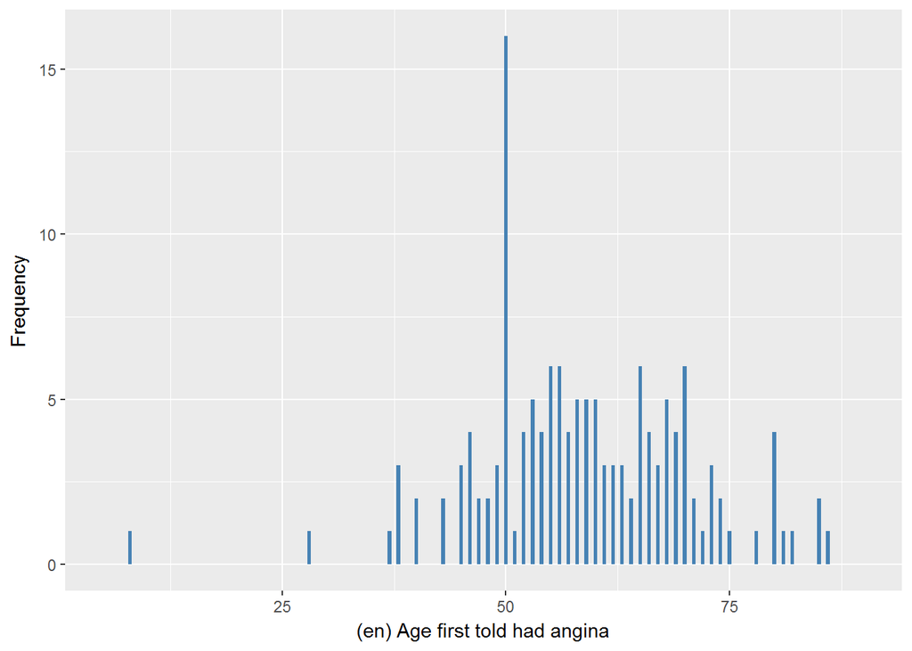

#### 2.1.4.2 Harmonisation algorithm

To compute `h_angina` from the study-specific variable it has to be recoded as follows:

- `h_angina previous == 1 or hediman == 1 into 1`
- `h_angina previous != 1 and hediman == -9 into 997`
- `h_angina previous != 1 and hediman == -8 into 998`
- `h_angina previous != 1 and hediman == 0 into 0`

To compute `h_angina_age` from the study-specific variable it has to be recoded as follows:

- `if h_angina == 1, h_angina_age = heaga`
- `if h_angina == 0, h_angina_age = 996`
- `-9 into 997`
- `-8 into 998`
- `-2 into 991`
- `-1 into 996`
- `otherwise, h_angina_age = 999`

**R script:**

```r
ELSA_w4 <- left_join(ELSA_w4, ELSA_ds, by = "id")

# Categorical variable harmonization
ELSA_ds_w4 <- tibble(id = ELSA_w4$id)
ELSA_ds_w4$h_angina <- rep(999, length(ELSA_w4$id))
ELSA_ds_w4$h_angina[which(ELSA_w4$h_angina == 1 | ELSA_w4$hediman == 1)] <- 1
ELSA_ds_w4$h_angina[which((ELSA_w4$h_angina != 1 | is.na(ELSA_w4$h_angina)) &
    ELSA_w4$hediman == 0)] <- 0
ELSA_ds_w4$h_angina[which((ELSA_w4$h_angina != 1 | is.na(ELSA_w4$h_angina)) &
    ELSA_w4$hediman == -9)] <- 997
ELSA_ds_w4$h_angina[which((ELSA_w4$h_angina != 1 | is.na(ELSA_w4$h_angina)) &
    ELSA_w4$hediman == -8)] <- 998

# Continuous variable harmonization
ELSA_ds_w4$h_angina_age <- rep(999, length(ELSA_w4$id))
ELSA_ds_w4$h_angina_age[which(ELSA_ds_w4$h_angina == 0)] <- 996
ELSA_ds_w4$h_angina_age[which(ELSA_ds_w4$h_angina == 1)] <- car::recode(ELSA_w4$heaga[which(ELSA_ds_w4$h_angina ==
    1)], "-1=996;-2=991;-8=998;-9=997")
ELSA_ds_w4$h_angina_age[which(ELSA_ds_w4$h_angina == 1 & !is.na(ELSA_w4$h_angina_age) &
    !ELSA_w4$h_angina_age %in% miss_values_vector)] <- ELSA_w4$h_angina_age[which(ELSA_ds_w4$h_angina ==
    1 & !is.na(ELSA_w4$h_angina_age) & !ELSA_w4$h_angina_age %in% miss_values_vector)]

# Update of global table
assign_merge <- function(endtib, sttib, log_vec = c(T), col_end_index = NULL,
    col_st_index = NULL) {
    newtib <- full_join(endtib, sttib, by = "id")
    row.names(newtib) <- newtib$id
    newtib[log_vec, col_end_index] <- newtib[log_vec, col_st_index]
    id_ind <- match("id", names(newtib))
    newtib <- newtib[, c(id_ind, col_end_index)]
    names(newtib)[2] <- "x"
    newtib$x <- car::recode(newtib$x, "NA=999")
    names(newtib)[2] <- names(endtib)[col_end_index]
    newtib
}
ELSA_ds_prov <- ELSA_ds[, c(1, 2)]
ELSA_ds_prov <- assign_merge(ELSA_ds_prov, ELSA_ds_w4, log_vec = ELSA_ds_w4$id,
    col_end_index = 2, col_st_index = 3)
ELSA_ds_aux <- ELSA_ds[, c(1, 3)]
ELSA_ds_aux <- assign_merge(ELSA_ds_aux, ELSA_ds_w4, log_vec = ELSA_ds_w4$id[which(ELSA_ds_w4$h_angina !=
    999)], col_end_index = 2, col_st_index = 4)
ELSA_ds <- ELSA_ds_prov
ELSA_ds$h_angina_age <- ELSA_ds_aux$h_angina_age
rm(ELSA_ds_prov)
rm(ELSA_ds_aux)
```

#### 2.1.4.3 Statistics of the new harmonized variable

History of angina

| Sample size | Missing values |
| --- | --- |
| 11050 | 16 |

Category

|  | 0 | 1 |
| --- | --- | --- |
| Frequency | 10101.00 | 933.00 |
| Percentage | 91.41 | 8.44 |

Type of missing

|  | 991 | 992 | 993 | 994 | 995 | 996 | 997 | 998 | 999 | NA |
| --- | --- | --- | --- | --- | --- | --- | --- | --- | --- | --- |
| Frequency | 0 | 0 | 0 | 0 | 0 | 0 | 7.00 | 9.00 | 0 | 0 |
| Percentage | 0 | 0 | 0 | 0 | 0 | 0 | 0.06 | 0.08 | 0 | 0 |

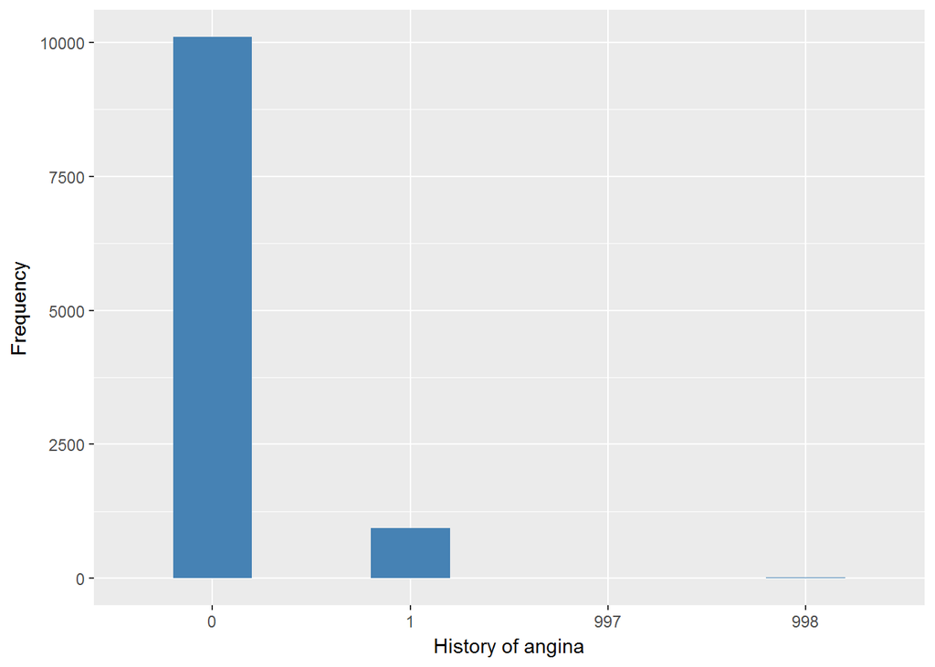

Age first diagnosed angina

| Sample size | Missing values |
| --- | --- |
| 11050 | 10493 |

Values

|  | No-missings | 991 | 992 | 993 | 994 | 995 | 996 | 997 | 998 | 999 | NA |
| --- | --- | --- | --- | --- | --- | --- | --- | --- | --- | --- | --- |
| Frequency | 557.00 | 3.00 | 0 | 0 | 0 | 0 | 10471.00 | 0 | 3.00 | 16.00 | 0 |
| Percentage | 5.04 | 0.03 | 0 | 0 | 0 | 0 | 94.76 | 0 | 0.03 | 0.14 | 0 |

Summary

| Min. | 1st Qu. | Median | Mean | 3rd Qu. | Max. |
| --- | --- | --- | --- | --- | --- |
| 25 | 51 | 59 | 59.02 | 66 | 89 |

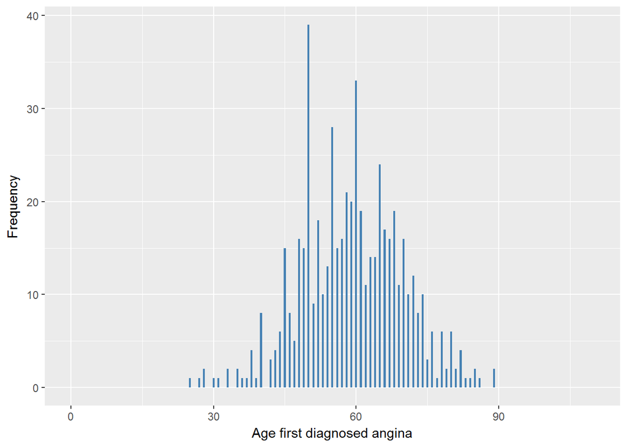

#### 2.1.4.4 Validation

|  | hediman==0->0 | hediman==1->1 | hediman==-9->997 | hediman==-8->998 |
| --- | --- | --- | --- | --- |
| BeforeH | 10101 | 933 | 7 | 9 |
| AfterH | 10101 | 933 | 7 | 9 |

### 2.1.5 Wave 5

#### 2.1.5.1 Study-specific variable description

| **Name** | `hediman` | `heaga` |
| --- | --- | --- |
| **Label** | `CVD: angina diagnosis newly reported (merged)` | `Age first told had angina` |
| **Table name** | `wave_5_elsa_data_v4` | `wave_5_elsa_data_v4` |
| **Categories** | `1 = Mentioned` `0 = Not mentioned` | `continuous` |
| **Missings** | `-9 = Refusal` `-8 = Don't know` `-1 = Not applicable` | `-9 = Refusal` `-8 = Don't know` `-1 = Not applicable` |
| **Description** |  |  |

hediman

| Sample size | Missing values |
| --- | --- |
| 10274 | 15 |

Category

|  | 0 | 1 |
| --- | --- | --- |
| Frequency | 10130.0 | 129.00 |
| Percentage | 98.6 | 1.26 |

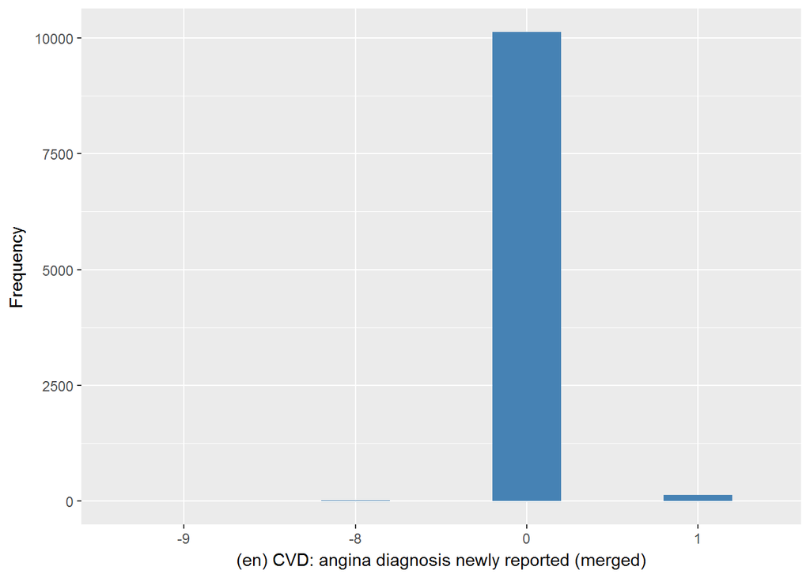

heaga

| Sample size | Missing values |
| --- | --- |
| 10274 | 10259 |

Summary

| Min. | 1st Qu. | Median | Mean | 3rd Qu. | Max. |
| --- | --- | --- | --- | --- | --- |
| 45 | 50.5 | 60 | 59.87 | 67 | 78 |

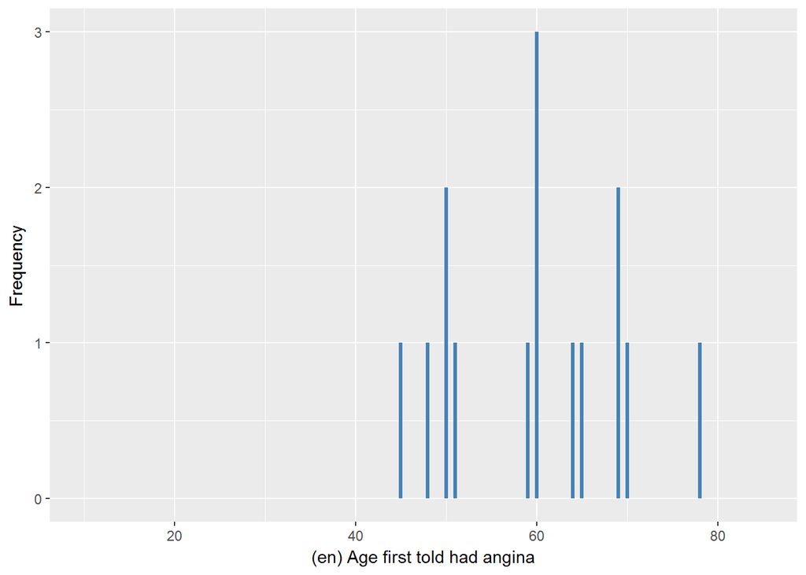

#### 2.1.5.2 Harmonisation algorithm

To compute `h_angina_age` from the study-specific variable it has to be recoded as follows:

- `if h_angina == 1, h_angina_age = heaga`
- `if h_angina == 0, h_angina_age = 996`
- `-9 into 997`
- `-8 into 998`
- `-1 into 996`
- `otherwise, h_angina_age = 999`

**R script:**

```r
ELSA_w5 <- left_join(ELSA_w5, ELSA_ds, by = "id")

# Categorical variable harmonization
ELSA_ds_w5 <- tibble(id = ELSA_w5$id)
ELSA_ds_w5$h_angina <- rep(999, length(ELSA_w5$id))
ELSA_ds_w5$h_angina[which(ELSA_w5$h_angina == 1 | ELSA_w5$hediman == 1)] <- 1
ELSA_ds_w5$h_angina[which((ELSA_w5$h_angina != 1 | is.na(ELSA_w5$h_angina)) &
    ELSA_w5$hediman == 0)] <- 0
ELSA_ds_w5$h_angina[which((ELSA_w5$h_angina != 1 | is.na(ELSA_w5$h_angina)) &
    ELSA_w5$hediman == -9)] <- 997
ELSA_ds_w5$h_angina[which((ELSA_w5$h_angina != 1 | is.na(ELSA_w5$h_angina)) &
    ELSA_w5$hediman == -8)] <- 998

# Continuous variable harmonization
ELSA_ds_w5$h_angina_age <- rep(999, length(ELSA_w5$id))
ELSA_ds_w5$h_angina_age[which(ELSA_ds_w5$h_angina == 0)] <- 996
ELSA_ds_w5$h_angina_age[which(ELSA_ds_w5$h_angina == 1)] <- car::recode(ELSA_w5$heaga[which(ELSA_ds_w5$h_angina ==
    1)], "-1=996;-2=991;-8=998;-9=997")
ELSA_ds_w5$h_angina_age[which(ELSA_ds_w5$h_angina == 1 & !is.na(ELSA_w5$h_angina_age) &
    !ELSA_w5$h_angina_age %in% miss_values_vector)] <- ELSA_w5$h_angina_age[which(ELSA_ds_w5$h_angina ==
    1 & !is.na(ELSA_w5$h_angina_age) & !ELSA_w5$h_angina_age %in% miss_values_vector)]

# Update of global table
assign_merge <- function(endtib, sttib, log_vec = c(T), col_end_index = NULL,
    col_st_index = NULL) {
    newtib <- full_join(endtib, sttib, by = "id")
    row.names(newtib) <- newtib$id
    newtib[log_vec, col_end_index] <- newtib[log_vec, col_st_index]
    id_ind <- match("id", names(newtib))
    newtib <- newtib[, c(id_ind, col_end_index)]
    names(newtib)[2] <- "x"
    newtib$x <- car::recode(newtib$x, "NA=999")
    names(newtib)[2] <- names(endtib)[col_end_index]
    newtib
}
ELSA_ds_prov <- ELSA_ds[, c(1, 2)]
ELSA_ds_prov <- assign_merge(ELSA_ds_prov, ELSA_ds_w5, log_vec = ELSA_ds_w5$id,
    col_end_index = 2, col_st_index = 3)
ELSA_ds_aux <- ELSA_ds[, c(1, 3)]
ELSA_ds_aux <- assign_merge(ELSA_ds_aux, ELSA_ds_w5, log_vec = ELSA_ds_w5$id[which(ELSA_ds_w5$h_angina !=
    999)], col_end_index = 2, col_st_index = 4)
ELSA_ds <- ELSA_ds_prov
ELSA_ds$h_angina_age <- ELSA_ds_aux$h_angina_age
rm(ELSA_ds_prov)
rm(ELSA_ds_aux)
```